# Toilet Not Usable

```python
"""import the libraries required"""
import pandas as pd
import string
import matplotlib.pyplot as plt
import numpy as np
```

```python
"""Meta Data"""
"""Define Categories of the Data"""
cat_type_yes_no_h = pd.CategoricalDtype(categories=["हाँ", "नहीं"], ordered=False)
cat_type_eco_status = pd.CategoricalDtype(categories=["BPL", "APL"], ordered=False)
cat_type_sub_cat = pd.CategoricalDtype(categories=["Small & Marginal Farmers",
                                                   "Other",
                                                  "GENERAL",
                                                  "ST",
                                                  "SC",
                                                  "Landless with homestead",
                                                   "Women Headed HH",
                                                   "PH"], ordered=False)
cat_type_toilet_type_h = pd.CategoricalDtype(categories=["दो गड्ढे वाला",
                                                       "सेप्टिक टैंक",
                                                       "एक गड्ढे वाला",
                                                       "उपलब्ध नहीं है",
                                                       "सोखते गड्ढे के साथ सेप्टिक टैंक",
                                                       "बायो-शौचालय"], ordered=False)
cat_type_water_source_type_h = pd.CategoricalDtype(categories=["हैंडपंप",
                                                         "कुआँ",
                                                         "नल-जल",
                                                         "उपलब्ध नहीं है",
                                                         "पानी का कोई स्त्रोत नहीं",
                                                         "तालाब"], ordered=False)
```

```python
"""Define the columns (if file does not have header row)"""
col_names = ["District",
             "Janpad",
             "Gram Panchayat",
             "Village",
             "Name of head of household",
             "GOI ID",
             "Column_1",
             "Economic status",
             "Sub-category",
             "Has Toilet",
             "Type of toilet",
             "Is the toilet being used",
             "Water source",
             "Reason for not using"]
```

```python
"""Define the data types for the columns"""
col_types =                           {"District":'category',
                                      "Janpad":'category',
                                      "Gram Panchayat":'category',
                                      "Village":'category',
                                      "Name of head of household":str,
                                      "GOI ID":str,
                                      "Column_1":str,
                                      "Economic status":cat_type_eco_status,
                                      "Sub-category":cat_type_sub_cat,
                                      "Has Toilet":cat_type_yes_no_h,
                                      "Type of toilet":cat_type_toilet_type_h,
                                      "Is the toilet being used":cat_type_yes_no_h,
                                      "Water source":cat_type_water_source_type_h,
                                      "Reason for not using":str}
```

```python
"Read the CSV File as a dataframe"
raw_data = pd.read_csv("D:\\My Freelancing Projects\\Water Aid\\Jal Shakti Charitable Foundation - Data Cleaning and Analysis\\Data Playground\\MP Gov\\Toilet_Not_Usable_Details.csv",
                               header=0,
                               names=col_names,
                               dtype=col_types,
                               index_col=False)
```

# Section 1: Information about the file -

1. Total records (RangeIndex)
2. Number of Columns (Data Columns)
3. Column Names and Data Type

```python
"""Check the file information"""
raw_data.info()
```

```
<class 'pandas.core.frame.DataFrame'>
RangeIndex: 992035 entries, 0 to 992034
Data columns (total 14 columns):
District                     992035 non-null category
Janpad                       992035 non-null category
Gram Panchayat               992035 non-null category
Village                      992035 non-null category
Name of head of household    992035 non-null object
GOI ID                       992035 non-null object
Column_1                     0 non-null object
Economic status              992035 non-null category
Sub-category                 992035 non-null category
Has Toilet                   992035 non-null category
Type of toilet               992035 non-null category
Is the toilet being used     992035 non-null category
Water source                 992035 non-null category
Reason for not using         554194 non-null object
dtypes: category(10), object(4)
memory usage: 44.1+ MB
```

# Section 2: Snapshot of the data -

1. Count - Total number of items in each column
2. Unique - Total number of Unique Items. E.g. Unique count for District = 51 implies that data from 51 districts
3. Top* - Most frequent value
4. Frequency* - Number of times the most frequent value has appeared

*Not relevant for analysis here

```python
"""Description about the data"""
raw_data.describe()
```

|  | District | Janpad | Gram Panchayat | Village | Name of head of household | GOI ID | Column_1 | Economic status | Sub-category | Has Toilet | Type of toilet | Is the toilet being used | Water source | Reason for not using |
| --- | --- | --- | --- | --- | --- | --- | --- | --- | --- | --- | --- | --- | --- | --- |
| count | 992035 | 992035 | 992035 | 992035 | 992035 | 992035 | 0.0 | 992035 | 992035 | 992035 | 992035 | 992035 | 992035 | 554194 |
| unique | 51 | 311 | 14361 | 23247 | 595461 | 984640 | 0.0 | 2 | 8 | 2 | 6 | 1 | 6 | 4572 |
| top | SATNA | RAM NAGAR | Chhapara | Dungariya Chhapara | Ram Singh | 197302382 | NaN | BPL | ST | हाँ | उपलब्ध नहीं है | नहीं | हैंडपंप | [ गड्ढा नहीं है/टूटा-फूटा है ] |
| freq | 75489 | 22938 | 3567 | 3395 | 968 | 12 | NaN | 576986 | 349876 | 556045 | 437265 | 992035 | 459440 | 63261 |

```python
raw_data.shape
```

```
(992035, 14)
```

```python
raw_data.head(50)
```

|  | District | Janpad | Gram Panchayat | Village | Name of head of household | GOI ID | Column_1 | Economic status | Sub-category | Has Toilet | Type of toilet | Is the toilet being used | Water source | Reason for not using |
| --- | --- | --- | --- | --- | --- | --- | --- | --- | --- | --- | --- | --- | --- | --- |
| 0 | MORENA | MORENA | GADAJAR | Bastpur | Gopal Singh | 192478650 | NaN | APL | SC | हाँ | एक गड्ढे वाला | नहीं | हैंडपंप | [ पानी उपलब्ध नहीं है ] |
| 1 | MORENA | MORENA | GADAJAR | Bastpur | Lakhan nath | 192806246 | NaN | APL | SC | नहीं | उपलब्ध नहीं है | नहीं | पानी का कोई स्त्रोत नहीं | NaN |
| 2 | MORENA | MORENA | GADAJAR | Bastpur | Dalveer Singh | 192478651 | NaN | APL | SC | नहीं | उपलब्ध नहीं है | नहीं | हैंडपंप | NaN |
| 3 | MORENA | MORENA | GADAJAR | Bastpur | Kitabi Nath | 192660689 | NaN | APL | SC | नहीं | उपलब्ध नहीं है | नहीं | पानी का कोई स्त्रोत नहीं | NaN |
| 4 | MORENA | PAHARGARH | DHURKUDA | Dhurkuda | Thasingh | 192488381 | NaN | BPL | GENERAL | नहीं | उपलब्ध नहीं है | नहीं | पानी का कोई स्त्रोत नहीं | NaN |
| 5 | MORENA | PAHARGARH | DHURKUDA | Dhurkuda | Gopi | 3655215 | NaN | APL | Small & Marginal Farmers | नहीं | उपलब्ध नहीं है | नहीं | पानी का कोई स्त्रोत नहीं | NaN |
| 6 | MORENA | PAHARGARH | DHURKUDA | Dhurkuda | Hakim | 192484143 | NaN | APL | Other | नहीं | उपलब्ध नहीं है | नहीं | पानी का कोई स्त्रोत नहीं | NaN |
| 7 | MORENA | PAHARGARH | DHURKUDA | Dhurkuda | Anar Singh | 192385357 | NaN | BPL | GENERAL | नहीं | उपलब्ध नहीं है | नहीं | पानी का कोई स्त्रोत नहीं | NaN |
| 8 | MORENA | PAHARGARH | DHURKUDA | Dhurkuda | Pancham Singh | 192262456 | NaN | BPL | GENERAL | नहीं | उपलब्ध नहीं है | नहीं | पानी का कोई स्त्रोत नहीं | NaN |
| 9 | MORENA | PAHARGARH | DHURKUDA | Dhurkuda | Samant Dhakad | 192507558 | NaN | BPL | GENERAL | नहीं | उपलब्ध नहीं है | नहीं | पानी का कोई स्त्रोत नहीं | NaN |
| 10 | MORENA | JOURA | MAI | Mai | Phool Singh | 192316079 | NaN | APL | SC | हाँ | सोखते गड्ढे के साथ सेप्टिक टैंक | नहीं | पानी का कोई स्त्रोत नहीं | [ अन्य प्रयोजन हेतु उपयोग ] |
| 11 | MORENA | JOURA | MAI | Mai | Suneel Goud | 192384200 | NaN | BPL | GENERAL | नहीं | उपलब्ध नहीं है | नहीं | पानी का कोई स्त्रोत नहीं | NaN |
| 12 | MORENA | JOURA | MAI | Mai | Rajkumar Drji | 173218601 | NaN | APL | Small & Marginal Farmers | हाँ | एक गड्ढे वाला | नहीं | तालाब | [ अन्य सामान रखने हेतु उपयोग ] |
| 13 | MORENA | JOURA | MAI | Mai | rajkumar | 105548451 | NaN | APL | Small & Marginal Farmers | हाँ | बायो-शौचालय | नहीं | कुआँ | [ सीट के साथ वाटर सील कनैक्ट नहीं है ] |
| 14 | MORENA | JOURA | MAI | Mai | Rambhajan Kirar | 173229831 | NaN | APL | Small & Marginal Farmers | नहीं | उपलब्ध नहीं है | नहीं | पानी का कोई स्त्रोत नहीं | NaN |
| 15 | MORENA | JOURA | MAI | Mai | ramnivas | 105547806 | NaN | APL | Small & Marginal Farmers | हाँ | एक गड्ढे वाला | नहीं | पानी का कोई स्त्रोत नहीं | [ सीट नहीं है ] |
| 16 | MORENA | JOURA | MAI | Mai | Sarman Singh Yadav | 192369326 | NaN | BPL | GENERAL | नहीं | उपलब्ध नहीं है | नहीं | पानी का कोई स्त्रोत नहीं | NaN |
| 17 | MORENA | JOURA | MAI | Mai | Kanhaila Lal | 173835078 | NaN | BPL | SC | हाँ | सेप्टिक टैंक | नहीं | कुआँ | [ कैप नहीं है ] |
| 18 | MORENA | JOURA | MAI | Mai | Aasharam Yadav | 192380389 | NaN | BPL | GENERAL | नहीं | उपलब्ध नहीं है | नहीं | पानी का कोई स्त्रोत नहीं | NaN |
| 19 | MORENA | JOURA | MAI | Mai | Lajjaram | 173777991 | NaN | BPL | SC | हाँ | एक गड्ढे वाला | नहीं | पानी का कोई स्त्रोत नहीं | [ दीवार नहीं है ] |
| 20 | MORENA | JOURA | MAI | Mai | puran | 48644441 | NaN | APL | Small & Marginal Farmers | हाँ | दो गड्ढे वाला | नहीं | तालाब | [ पानी उपलब्ध नहीं है ] |
| 21 | MORENA | JOURA | MAI | Mai | Kok Singh Kushawah | 172868802 | NaN | BPL | GENERAL | हाँ | एक गड्ढे वाला | नहीं | नल-जल | [ दरवाजा नहीं है ] |
| 22 | MORENA | JOURA | MAI | Mai | Parshram Shakya | 192408550 | NaN | BPL | SC | हाँ | दो गड्ढे वाला | नहीं | पानी का कोई स्त्रोत नहीं | [ कैप नहीं है ] |
| 23 | MORENA | JOURA | MAI | Mai | ramlkhan | 105548298 | NaN | APL | Small & Marginal Farmers | हाँ | सेप्टिक टैंक | नहीं | पानी का कोई स्त्रोत नहीं | [ पानी उपलब्ध नहीं है ] |
| 24 | MORENA | JOURA | MAI | Mai | sundrsingh | 48646217 | NaN | APL | Small & Marginal Farmers | नहीं | उपलब्ध नहीं है | नहीं | पानी का कोई स्त्रोत नहीं | NaN |
| 25 | MORENA | JOURA | MAI | Mai | hrioom | 48648312 | NaN | APL | Small & Marginal Farmers | नहीं | उपलब्ध नहीं है | नहीं | पानी का कोई स्त्रोत नहीं | NaN |
| 26 | MORENA | JOURA | MAI | Mai | bhagchandra | 48640461 | NaN | APL | Small & Marginal Farmers | हाँ | सोखते गड्ढे के साथ सेप्टिक टैंक | नहीं | पानी का कोई स्त्रोत नहीं | [ प्लेटफार्म नहीं है/टूटा फूटा है ] |
| 27 | MORENA | JOURA | MAI | Mai | dhurvsingh | 48651929 | NaN | APL | Small & Marginal Farmers | नहीं | उपलब्ध नहीं है | नहीं | पानी का कोई स्त्रोत नहीं | NaN |
| 28 | MORENA | JOURA | MAI | Mai | Hitendra Singh Rajpoot | 192430185 | NaN | APL | Other | हाँ | एक गड्ढे वाला | नहीं | कुआँ | [ कैप नहीं है ] |
| 29 | MORENA | JOURA | MAI | Mai | Jagannath Gaud | 175164184 | NaN | BPL | SC | हाँ | एक गड्ढे वाला | नहीं | नल-जल | [ कैप नहीं है ] |
| 30 | MORENA | JOURA | MAI | Mai | Sughar Singh Jataw | 192417641 | NaN | APL | SC | हाँ | एक गड्ढे वाला | नहीं | कुआँ | [ कैप नहीं है ] |
| 31 | MORENA | JOURA | MAI | Mai | Omprakash Shrivastav | 192377658 | NaN | APL | Other | नहीं | उपलब्ध नहीं है | नहीं | पानी का कोई स्त्रोत नहीं | NaN |
| 32 | MORENA | PORSA | BIJLIOURA | Bijlipura | ramnivash | 46008499 | NaN | APL | Small & Marginal Farmers | हाँ | एक गड्ढे वाला | नहीं | नल-जल | [ अन्य प्रयोजन हेतु उपयोग ] |
| 33 | MORENA | PAHARGARH | KOLHUDANDA | Kolhudanda | Jandel Singh | 192596885 | NaN | APL | Small & Marginal Farmers | हाँ | एक गड्ढे वाला | नहीं | हैंडपंप | [ गड्ढा नहीं है/टूटा-फूटा है ], [ सीट नहीं है ] |
| 34 | MORENA | PAHARGARH | KOLHUDANDA | Kolhudanda | Banvarilal Dhakar | 192718019 | NaN | BPL | GENERAL | हाँ | एक गड्ढे वाला | नहीं | हैंडपंप | [ गड्ढा नहीं है/टूटा-फूटा है ], [ दीवार नहीं ... |
| 35 | MORENA | PAHARGARH | KOLHUDANDA | Kolhudanda | Dharm Singh | 192602315 | NaN | BPL | GENERAL | हाँ | एक गड्ढे वाला | नहीं | हैंडपंप | [ गड्ढा नहीं है/टूटा-फूटा है ] |
| 36 | MORENA | PAHARGARH | KOLHUDANDA | Kolhudanda | Shivraj Singh Jadon | 192536421 | NaN | APL | Small & Marginal Farmers | हाँ | एक गड्ढे वाला | नहीं | पानी का कोई स्त्रोत नहीं | [ गड्ढा नहीं है/टूटा-फूटा है ] |
| 37 | MORENA | PAHARGARH | KOLHUDANDA | Kolhudanda | Lachmana Singh | 192648319 | NaN | APL | Small & Marginal Farmers | हाँ | एक गड्ढे वाला | नहीं | हैंडपंप | [ गड्ढा नहीं है/टूटा-फूटा है ], [ दीवार नहीं ... |
| 38 | MORENA | PAHARGARH | KOLHUDANDA | Kolhudanda | Rajendra Singh | 192616032 | NaN | APL | Small & Marginal Farmers | हाँ | एक गड्ढे वाला | नहीं | हैंडपंप | [ सीट नहीं है ] |
| 39 | MORENA | PAHARGARH | KOLHUDANDA | Kolhudanda | Lajjaram | 179873480 | NaN | APL | Small & Marginal Farmers | हाँ | एक गड्ढे वाला | नहीं | हैंडपंप | [ दीवार नहीं है ], [ सीट नहीं है ] |
| 40 | MORENA | PAHARGARH | KOLHUDANDA | Kolhudanda | Pradip Dhakad | 192581753 | NaN | BPL | GENERAL | हाँ | एक गड्ढे वाला | नहीं | हैंडपंप | [ गड्ढा नहीं है/टूटा-फूटा है ], [ सीट नहीं है ] |
| 41 | MORENA | PAHARGARH | KOLHUDANDA | Kolhudanda | Ugrsen Singh Parmar | 192607579 | NaN | APL | Small & Marginal Farmers | हाँ | एक गड्ढे वाला | नहीं | हैंडपंप | [ सीट नहीं है ] |
| 42 | MORENA | PAHARGARH | KOLHUDANDA | Kolhudanda | Jagram Dhakar | 192661260 | NaN | APL | Small & Marginal Farmers | हाँ | एक गड्ढे वाला | नहीं | हैंडपंप | [ गड्ढा नहीं है/टूटा-फूटा है ], [ सीट नहीं है ] |
| 43 | MORENA | PAHARGARH | BHARRA | Bharra | Surendra Singh | 192645778 | NaN | BPL | GENERAL | नहीं | उपलब्ध नहीं है | नहीं | पानी का कोई स्त्रोत नहीं | NaN |
| 44 | MORENA | PAHARGARH | BHARRA | Bharra | Nirpal | 192450988 | NaN | BPL | GENERAL | नहीं | उपलब्ध नहीं है | नहीं | पानी का कोई स्त्रोत नहीं | NaN |
| 45 | MORENA | PAHARGARH | BHARRA | Bharra | Amritlal | 192531154 | NaN | BPL | GENERAL | नहीं | उपलब्ध नहीं है | नहीं | पानी का कोई स्त्रोत नहीं | NaN |
| 46 | MORENA | PAHARGARH | BHARRA | Bharra | Dataram | 192455979 | NaN | BPL | GENERAL | नहीं | उपलब्ध नहीं है | नहीं | पानी का कोई स्त्रोत नहीं | NaN |
| 47 | MORENA | PAHARGARH | BHARRA | Bharra | Vishram | 192603885 | NaN | APL | SC | हाँ | एक गड्ढे वाला | नहीं | कुआँ | [ सीट नहीं है ] |
| 48 | MORENA | PAHARGARH | BHARRA | Bharra | Molaram Singh | 192509043 | NaN | APL | Small & Marginal Farmers | नहीं | उपलब्ध नहीं है | नहीं | पानी का कोई स्त्रोत नहीं | NaN |
| 49 | MORENA | PAHARGARH | BHARRA | Bharra | Murari | 192566084 | NaN | BPL | GENERAL | नहीं | उपलब्ध नहीं है | नहीं | पानी का कोई स्त्रोत नहीं | NaN |

```
True - Yes
False - No
```

```python
raw_data.empty
```

```
False
```

```python
"""Capitalize the Name of Districts"""
raw_data["District"] = raw_data["District"].str.upper()

"""Capitalize the Name of Janpad"""
raw_data["Janpad"] = raw_data["Janpad"].str.upper()

"""Capitalize the Name of Gram Panchayat"""
raw_data["Gram Panchayat"] = raw_data["Gram Panchayat"].str.upper()

"""Capitalize the Name of Village"""
raw_data["Village"] = raw_data["Village"].str.upper()

"""Capitalize the Name of Head of Household"""
raw_data["Name of head of household"] = raw_data["Name of head of household"].str.upper()
```

## Identify duplicate records

Based on the combination - District+Janpad+Gram Panchayat+Village+Name of head of household+GOI ID

```python
raw_data["is_duplicate_record"] = raw_data.duplicated(subset=("District",
             "Janpad",
             "Gram Panchayat",
             "Village",
             "Name of head of household",
             "GOI ID"))
```

# Section 3: Data Error Checks

## 1. Total Duplicate records:

```python
"""Data Error Condition 1: Number of Duplicate Records identified using Duplicate Key above"""
raw_data[raw_data["is_duplicate_record"] == True].shape[0]
```

```
7285
```

## 2. Missing Data in Mandatory Columns:

```python
"""Data Error Condition 2: Check Missing Data in the mandatory columns"""
for label, content in raw_data.items():
    """Apply the condition in all columns except"""
    if label not in ["District",
             "Janpad",
             "Gram Panchayat",
             "Village",
             "Name of head of household",
             "GOI ID",
             "is_duplicate_record",
             "Reason for not using"]:
        print("-----")
        print(content.value_counts())
        if content.isnull().any():
            print("NULL Values: ",content.isnull().shape[0])
        elif content.isna().any():
            print("Missing Data: ",content.isna().shape[0])
        else:
            print("Missing Data: ",0)
```

```
-----
Series([], Name: Column_1, dtype: int64)
NULL Values:  992035
-----
BPL    576986
APL    415049
Name: Economic status, dtype: int64
Missing Data:  0
-----
ST                          349876
GENERAL                     227858
Other                       187246
SC                          133419
Small & Marginal Farmers     64080
Women Headed HH              21302
Landless with homestead       5638
PH                            2616
Name: Sub-category, dtype: int64
Missing Data:  0
-----
हाँ     556045
नहीं    435990
Name: Has Toilet, dtype: int64
Missing Data:  0
-----
उपलब्ध नहीं है                     437265
एक गड्ढे वाला                      345102
दो गड्ढे वाला                      171694
सेप्टिक टैंक                        24861
सोखते गड्ढे के साथ सेप्टिक टैंक     11406
बायो-शौचालय                          1707
Name: Type of toilet, dtype: int64
Missing Data:  0
-----
नहीं    992035
हाँ          0
Name: Is the toilet being used, dtype: int64
Missing Data:  0
-----
हैंडपंप                     459440
कुआँ                        183236
पानी का कोई स्त्रोत नहीं    178258
नल-जल                       148600
उपलब्ध नहीं है               15964
तालाब                         6537
Name: Water source, dtype: int64
Missing Data:  0
```

### Observations:

a. All the values in Column_1 are missing. b. There is no other missing value error.

## 3. Number of records where toilet is available in the household but type of toilet has either not been provided or mentioned as not available -

```python
"""Data Error Condition 3: Number of Records where toilet is available but type of toilet has been mentioned उपलब्ध नहीं है"""
raw_data[(raw_data["Has Toilet"] == 'हाँ') & (raw_data["Type of toilet"] == 'उपलब्ध नहीं है')].shape[0]
```

```
1641
```

## 4. Number of records where toilet is not available in the household but type of toilet has been mentioned -

```python
"""Data Error Condition 4: Number of Records where toilet is not available but type of toilet has been mentioned other than उपलब्ध नहीं है"""
raw_data[(raw_data["Has Toilet"] == 'नहीं') & (raw_data["Type of toilet"] != 'उपलब्ध नहीं है')].shape[0]
```

```
366
```

## 5. Number of records where toilet is not available in the household but reason for not using it is mentioned -

```python
"""Data Error Condition 3: Number of Records where water source is available but type of source has been mentioned as not available"""
raw_data[(raw_data["Has Toilet"] == 'नहीं') & (raw_data["Reason for not using"].isna() == False)].shape[0]
```

```
2915
```

# Section 2: Data Analysis

## 1. Overview

### Total Households Surveyed in Reverification of Toilet:

```python
raw_data.shape[0]
```

```
992035
```

```python
plt.figure()
```

### Households by Economic Status

```
Number of households in
-----------------------
BPL    576986
APL    415049
Name: Economic status, dtype: int64
-----------------------
% of households in
-----------------------
BPL    58.161859
APL    41.838141
Name: Economic status, dtype: float64
-----------------------
```

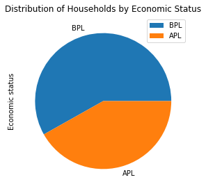

```python
print("Number of households in")
print("-----------------------")
hh_by_eco_status_cnt = raw_data["Economic status"].value_counts()
print(hh_by_eco_status_cnt)
print("-----------------------")
print("% of households in")
print("-----------------------")
hh_by_eco_status_pct = raw_data["Economic status"].value_counts(normalize=True)*100
print(hh_by_eco_status_pct)
print("-----------------------")
hh_by_eco_status_pct.plot.pie(figsize=[8,4.5],
                          title="Distribution of Households by Economic Status",
                          legend=True)
```

#### Observations:

1. 58.16% of the households where toilet is not usable belong to BPL category.

### Households by Social Category

```
Number of households in
-----------------------
ST                          349876
GENERAL                     227858
Other                       187246
SC                          133419
Small & Marginal Farmers     64080
Women Headed HH              21302
Landless with homestead       5638
PH                            2616
Name: Sub-category, dtype: int64
-----------------------
% of households in
-----------------------
ST                          35.268514
GENERAL                     22.968746
Other                       18.874939
SC                          13.449021
Small & Marginal Farmers     6.459450
Women Headed HH              2.147303
Landless with homestead      0.568327
PH                           0.263700
Name: Sub-category, dtype: float64
-----------------------
```

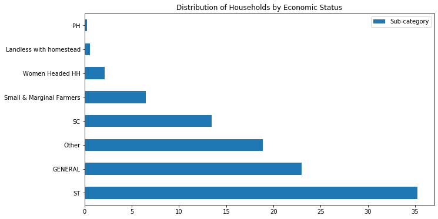

```python
print("Number of households in")
print("-----------------------")
hh_by_sco_catgry_cnt = raw_data["Sub-category"].value_counts()
print(hh_by_sco_catgry_cnt)
print("-----------------------")
print("% of households in")
print("-----------------------")
hh_by_sco_catgry_pct = raw_data["Sub-category"].value_counts(normalize=True)*100
print(hh_by_sco_catgry_pct)
print("-----------------------")
hh_by_sco_catgry_pct.plot.barh(figsize=[10.66,6],
                          title="Distribution of Households by Economic Status",
                          legend=True)
```

### Households by Economic Status and Social Category

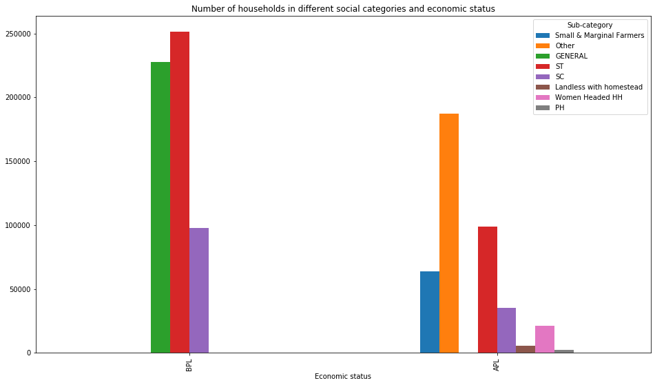

```python
pd.crosstab(index=raw_data["Economic status"],
                          columns=raw_data["Sub-category"]).plot.bar(figsize=[16,9],
                                                                    title="Number of households in different social categories and economic status",
                                                                    table=False)
```

#### Observations -

1. There are 18.88% households in "Others" category
2. All the General category households are BPL
3. BPL Households has only General, SC and ST category. No landless family, or household headed by a woman or physically challenged person has been reported as BPL.

## 2. Status of Toilets in Households

### Availability of Toilets in the Households

```python
print("Number of households having toilet")
print("-----------------------")
hh_hvng_tlt_cnt = raw_data["Has Toilet"].value_counts()
print(hh_hvng_tlt_cnt)
print("-----------------------")
print("% of households having toilet")
print("-----------------------")
hh_hvng_tlt_pct = raw_data["Has Toilet"].value_counts(normalize=True)*100
print(hh_hvng_tlt_pct)
print("-----------------------")
```

```
Number of households having toilet
-----------------------
हाँ     556045
नहीं    435990
Name: Has Toilet, dtype: int64
-----------------------
% of households having toilet
-----------------------
हाँ     56.050946
नहीं    43.949054
Name: Has Toilet, dtype: float64
-----------------------
```

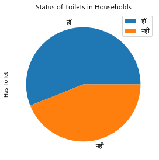

```python
plt.rcParams['font.family']='Nirmala UI'

hh_hvng_tlt_pct.plot.pie(figsize=[8,4.5],
                          title="Status of Toilets in Households",
                          legend=True)
```

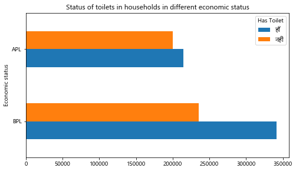

```python
pd.crosstab(index=raw_data["Economic status"],
                          columns=raw_data["Has Toilet"]).plot.barh(figsize=[8,4.5],
                                                                    title="Status of toilets in households in different economic status",
                                                                    table=False)
```

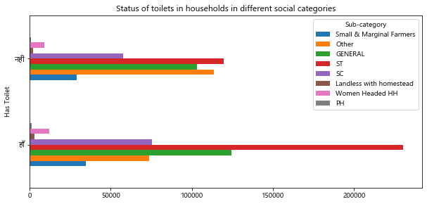

```python
pd.crosstab(index=raw_data["Has Toilet"],
                          columns=raw_data["Sub-category"]).plot.barh(figsize=[10,4.5],
                                                                    title="Status of toilets in households in different social categories",
                                                                    table=False)
```

#### Observations:

1. 43% of the housheolds surveyed for unusable toilet has reported that they don't have toilet i.e. 4.36 lakh such households are there

### Availabilty of Different Types of Toilet across Households

```python
hh_with_toilet = raw_data[(raw_data["Has Toilet"] == 'हाँ') & (raw_data["Type of toilet"] != 'उपलब्ध नहीं है')]
```

```python
print("Number of households having different types toilet")
print("--------------------------------------------------")
hh_hvng_tlt_type_cnt = hh_with_toilet["Type of toilet"].value_counts()
print(hh_hvng_tlt_type_cnt)
print("--------------------------------------------------")
print("% of households haing different types of toilet")
print("--------------------------------------------------")
hh_hvng_tlt_type_pct = hh_with_toilet["Type of toilet"].value_counts(normalize=True)*100
print(hh_hvng_tlt_type_pct)
print("--------------------------------------------------")
```

```
Number of households having different types toilet
--------------------------------------------------
एक गड्ढे वाला                      344800
दो गड्ढे वाला                      171656
सेप्टिक टैंक                        24842
सोखते गड्ढे के साथ सेप्टिक टैंक     11399
बायो-शौचालय                          1707
उपलब्ध नहीं है                          0
Name: Type of toilet, dtype: int64
--------------------------------------------------
% of households haing different types of toilet
--------------------------------------------------
एक गड्ढे वाला                      62.192913
दो गड्ढे वाला                      30.962259
सेप्टिक टैंक                        4.480848
सोखते गड्ढे के साथ सेप्टिक टैंक     2.056082
बायो-शौचालय                         0.307898
उपलब्ध नहीं है                      0.000000
Name: Type of toilet, dtype: float64
--------------------------------------------------
```

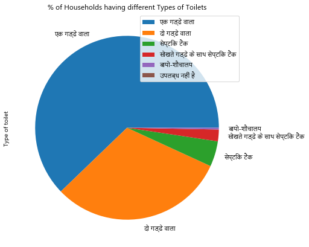

```python
hh_hvng_tlt_type_pct.plot.pie(figsize=[10,7],
                          title="% of Households having different Types of Toilets",
                          legend=True)
```

### Reasons for Not Using the Toilet

[ सीट नहीं है ] [ सीट के साथ वाटर सील कनैक्ट नहीं है ] [ प्लेटफार्म नहीं है/टूटा फूटा है ] [ पानी उपलब्ध नहीं है ] [ पशु घर के रूप में उपयोग ] [ दीवार नहीं है ] [ दरवाजा नहीं है ] [ चेम्बर नहीं है ] [ गड्ढा भरा हुआ है ] [ गड्ढा नहीं है/टूटा-फूटा है ] [ कैप नहीं है ] [ अन्य सामान रखने हेतु उपयोग ] [ अन्य प्रयोजन हेतु उपयोग ]

```python
"""Uniquely identify the reasons for not using toilet"""
raw_data['No Toilet Seat']=np.where(raw_data['Reason for not using'].str.contains("सीट नहीं है")==True,1,0)
raw_data['Water Seal Not Connected to Toilet Seat']=np.where(raw_data['Reason for not using'].str.contains( "सीट के साथ वाटर सील कनैक्ट नहीं है")==True,1,0)
raw_data['No/Broken Platform']=np.where(raw_data['Reason for not using'].str.contains( "लेटफार्म नहीं है/टूटा फूटा है")==True,1,0)
raw_data['No Water']=np.where(raw_data['Reason for not using'].str.contains( "पानी उपलब्ध नहीं है")==True,1,0)
raw_data['Used as Animal Shelter']=np.where(raw_data['Reason for not using'].str.contains( "पशु घर के रूप में  उपयोग")==True,1,0)
raw_data['No Wall']=np.where(raw_data['Reason for not using'].str.contains( "दीवार नहीं है")==True,1,0)
raw_data['No Door']=np.where(raw_data['Reason for not using'].str.contains( "दरवाजा नहीं है")==True,1,0)
raw_data['No Chamber']=np.where(raw_data['Reason for not using'].str.contains( "चेम्बर नहीं है")==True,1,0)
raw_data['Pit Full']=np.where(raw_data['Reason for not using'].str.contains( "गड्ढा भरा हुआ है")==True,1,0)
raw_data['No/Broken Pit']=np.where(raw_data['Reason for not using'].str.contains( "गड्ढा नहीं है")==True,1,0)
raw_data['No Cap']=np.where(raw_data['Reason for not using'].str.contains( "कैप नहीं है")==True,1,0)
raw_data['Used as Storage']=np.where(raw_data['Reason for not using'].str.contains( "अन्य सामान रखने हेतु उपयोग")==True,1,0)
raw_data['Used for other purpose']=np.where(raw_data['Reason for not using'].str.contains( "अन्य प्रयोजन हेतु उपयोग")==True,1,0)
raw_data['No Reason']=np.where(raw_data['Reason for not using'].isna()==True,1,0)
```

```python
raw_data['State']= "Madhya Pradesh"
```

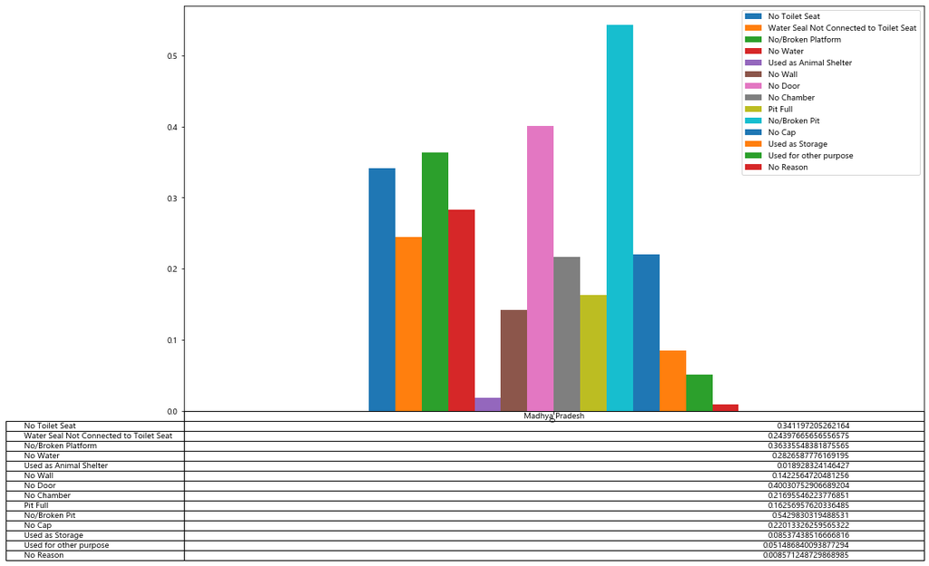

```python
reasons = raw_data[raw_data['Has Toilet']=="हाँ"].groupby('State').agg(np.mean)
reasons.plot.bar(y=['No Toilet Seat',
                                                  'Water Seal Not Connected to Toilet Seat',
                                                  'No/Broken Platform',
                                                  'No Water',
                                                  'Used as Animal Shelter',
                                                  'No Wall',
                                                  'No Door',
                                                  'No Chamber',
                                                  'Pit Full',
                                                  'No/Broken Pit',
                                                  'No Cap',
                                                  'Used as Storage',
                                                  'Used for other purpose',
                                                  'No Reason'
                                                 ],
                                               figsize=[16,9],
                                               use_index=False,
                                              subplots=False,
                                                table=True)
```

#### Observation:

Major reasons for no usage of toilet is the superstructure defect

1. 54% of the households having toilet are not using it due to lack of or broken Pit.
2. 40% of the households having toilet are not using it in lack of a door.
3. 36% of the households having toilet are not using it due to lack of or broken Platform.
4. 34% of the households having toilet are not using it due to lack of toilet seat.
5. 28% of the households having toilet are not using it due to lack of water.

```python
raw_data['Total Household'] = 1
```

### Prominent reasons for no use of toilets across Districts

```python
raw_data.pivot_table(index=['State','District'],
                     values=['Total Household',
                            'No Toilet Seat',
                            'Water Seal Not Connected to Toilet Seat',
                            'No/Broken Platform',
                            'No Water',
                            'Used as Animal Shelter',
                            'No Wall',
                            'No Door',
                            'No Chamber',
                            'Pit Full',
                            'No/Broken Pit',
                            'No Cap',
                            'Used as Storage',
                            'Used for other purpose',
                            'No Reason'],
                     aggfunc={'Total Household':np.sum,
                            'No Toilet Seat':np.mean,
                            'Water Seal Not Connected to Toilet Seat':np.mean,
                            'No/Broken Platform':np.mean,
                            'No Water':np.mean,
                            'Used as Animal Shelter':np.mean,
                            'No Wall':np.mean,
                            'No Door':np.mean,
                            'No Chamber':np.mean,
                            'Pit Full':np.mean,
                            'No/Broken Pit':np.mean,
                            'No Cap':np.mean,
                            'Used as Storage':np.mean,
                            'Used for other purpose':np.mean,
                            'No Reason':np.mean},
                    margins=True)
```

| State | District | No Cap | No Chamber | No Door | No Reason | No Toilet Seat | No Wall | No Water | No/Broken Pit | No/Broken Platform | Pit Full | Total Household | Used as Animal Shelter | Used as Storage | Used for other purpose | Water Seal Not Connected to Toilet Seat |
| --- | --- | --- | --- | --- | --- | --- | --- | --- | --- | --- | --- | --- | --- | --- | --- | --- |
| Madhya Pradesh | AGAR MALWA | 0.062302 | 0.058923 | 0.166420 | 0.590496 | 0.195987 | 0.091658 | 0.170433 | 0.101584 | 0.157128 | 0.057867 | 4735 | 0.020063 | 0.048997 | 0.027878 | 0.073073 |
|  | ALIRAJPUR | 0.037751 | 0.048193 | 0.167336 | 0.228648 | 0.118876 | 0.026506 | 0.197858 | 0.397858 | 0.129853 | 0.026238 | 3735 | 0.007229 | 0.040696 | 0.020616 | 0.042303 |
|  | ANUPPUR | 0.215651 | 0.129676 | 0.233385 | 0.159641 | 0.110676 | 0.037406 | 0.158176 | 0.571310 | 0.231208 | 0.065867 | 25263 | 0.005463 | 0.062740 | 0.036338 | 0.114119 |
|  | ASHOKNAGAR | 0.104141 | 0.075378 | 0.127201 | 0.218696 | 0.203571 | 0.080089 | 0.216464 | 0.452517 | 0.209273 | 0.057773 | 4033 | 0.008926 | 0.074138 | 0.042400 | 0.097446 |
|  | BALAGHAT | 0.146274 | 0.149758 | 0.322999 | 0.467851 | 0.254173 | 0.139075 | 0.107376 | 0.291039 | 0.244710 | 0.106592 | 34449 | 0.010276 | 0.040117 | 0.032251 | 0.140033 |
|  | BARWANI | 0.050711 | 0.080794 | 0.097914 | 0.534468 | 0.127347 | 0.031837 | 0.178871 | 0.304334 | 0.115360 | 0.075889 | 30782 | 0.003021 | 0.018387 | 0.011598 | 0.084108 |
|  | BETUL | 0.091231 | 0.103141 | 0.230322 | 0.410292 | 0.156594 | 0.054506 | 0.096327 | 0.321332 | 0.196976 | 0.070902 | 18053 | 0.005262 | 0.030466 | 0.016230 | 0.117377 |
|  | BHIND | 0.027618 | 0.021856 | 0.038943 | 0.726604 | 0.053646 | 0.023247 | 0.045102 | 0.119809 | 0.059805 | 0.017485 | 5033 | 0.002583 | 0.021458 | 0.015696 | 0.048480 |
|  | BHOPAL | 0.039600 | 0.039244 | 0.262933 | 0.519443 | 0.099179 | 0.060649 | 0.095255 | 0.143061 | 0.089547 | 0.045665 | 2803 | 0.001784 | 0.002854 | 0.001427 | 0.037460 |
|  | BURHANPUR | 0.059051 | 0.051584 | 0.246760 | 0.456184 | 0.260922 | 0.104798 | 0.181959 | 0.240151 | 0.200927 | 0.112265 | 11651 | 0.003347 | 0.011844 | 0.037164 | 0.093297 |
|  | CHHATARPUR | 0.097131 | 0.119831 | 0.118543 | 0.449819 | 0.144291 | 0.049025 | 0.197467 | 0.243340 | 0.203563 | 0.057301 | 38062 | 0.009222 | 0.083784 | 0.043534 | 0.150176 |
|  | CHHINDWARA | 0.069435 | 0.097896 | 0.278783 | 0.342268 | 0.169662 | 0.050666 | 0.128320 | 0.321475 | 0.179108 | 0.097344 | 16303 | 0.005336 | 0.025149 | 0.012268 | 0.118444 |
|  | DAMOH | 0.118506 | 0.117924 | 0.209672 | 0.402395 | 0.211549 | 0.055868 | 0.191349 | 0.386002 | 0.268158 | 0.107004 | 37821 | 0.012268 | 0.061130 | 0.047064 | 0.165781 |
|  | DATIA | 0.021725 | 0.026428 | 0.050840 | 0.759910 | 0.071892 | 0.035610 | 0.042105 | 0.105039 | 0.059574 | 0.013214 | 4465 | 0.003583 | 0.021501 | 0.007167 | 0.058903 |
|  | DEWAS | 0.052934 | 0.043447 | 0.164860 | 0.651626 | 0.121891 | 0.069914 | 0.082430 | 0.129066 | 0.104034 | 0.036272 | 12544 | 0.007892 | 0.017379 | 0.014429 | 0.053571 |
|  | DHAR | 0.077898 | 0.056071 | 0.217096 | 0.351196 | 0.219841 | 0.040779 | 0.195791 | 0.287675 | 0.175663 | 0.042347 | 7651 | 0.014769 | 0.040387 | 0.045484 | 0.071494 |
|  | DINDORI | 0.163879 | 0.189802 | 0.141480 | 0.382867 | 0.142704 | 0.020731 | 0.175524 | 0.393770 | 0.174152 | 0.068607 | 26965 | 0.001150 | 0.033265 | 0.007640 | 0.186575 |
|  | GUNA | 0.119876 | 0.109674 | 0.146216 | 0.424782 | 0.216379 | 0.074430 | 0.193053 | 0.308616 | 0.190549 | 0.096457 | 21564 | 0.016555 | 0.063996 | 0.038305 | 0.136570 |
|  | GWALIOR | 0.042689 | 0.031894 | 0.064769 | 0.578999 | 0.116781 | 0.033857 | 0.158489 | 0.156035 | 0.120216 | 0.029931 | 2038 | 0.007851 | 0.053974 | 0.042689 | 0.069676 |
|  | HARDA | 0.081304 | 0.066211 | 0.336687 | 0.331656 | 0.121956 | 0.132824 | 0.099416 | 0.192393 | 0.206681 | 0.213524 | 4969 | 0.003421 | 0.022540 | 0.003421 | 0.056752 |
|  | HOSHANGABAD | 0.107820 | 0.091695 | 0.232715 | 0.384380 | 0.142180 | 0.069562 | 0.100337 | 0.327466 | 0.208474 | 0.116568 | 9488 | 0.000738 | 0.003056 | 0.001370 | 0.128689 |
|  | INDORE | 0.049315 | 0.042922 | 0.344292 | 0.457534 | 0.162557 | 0.147032 | 0.089498 | 0.085845 | 0.161644 | 0.044749 | 1095 | 0.006393 | 0.025571 | 0.010046 | 0.052968 |
|  | JABALPUR | 0.097567 | 0.097873 | 0.205069 | 0.670102 | 0.159482 | 0.134330 | 0.096762 | 0.171157 | 0.165005 | 0.088420 | 62101 | 0.009195 | 0.026586 | 0.015282 | 0.092575 |
|  | JHABUA | 0.087513 | 0.116559 | 0.134077 | 0.221964 | 0.204896 | 0.051505 | 0.106827 | 0.543644 | 0.212307 | 0.045815 | 13358 | 0.006214 | 0.050307 | 0.017742 | 0.123596 |
|  | KATNI | 0.138780 | 0.120235 | 0.283165 | 0.342255 | 0.230288 | 0.113836 | 0.174654 | 0.341882 | 0.243787 | 0.107577 | 21408 | 0.020039 | 0.046665 | 0.035267 | 0.149664 |
|  | KHANDWA | 0.054030 | 0.047537 | 0.141716 | 0.545448 | 0.185075 | 0.067090 | 0.134403 | 0.176418 | 0.139552 | 0.037388 | 13400 | 0.004104 | 0.035224 | 0.032761 | 0.064552 |
|  | KHARGONE | 0.094844 | 0.108752 | 0.152380 | 0.510163 | 0.195862 | 0.057097 | 0.161945 | 0.292560 | 0.199595 | 0.077788 | 40983 | 0.005856 | 0.024278 | 0.031452 | 0.106776 |
|  | MANDLA | 0.154853 | 0.202182 | 0.221250 | 0.343965 | 0.201030 | 0.043369 | 0.212181 | 0.409555 | 0.244137 | 0.081850 | 49505 | 0.006666 | 0.074356 | 0.030704 | 0.225775 |
|  | MANDSAUR | 0.035823 | 0.038084 | 0.211895 | 0.448657 | 0.142509 | 0.059821 | 0.241196 | 0.156856 | 0.179028 | 0.044692 | 11501 | 0.003391 | 0.061386 | 0.019650 | 0.096687 |
|  | MORENA | 0.071828 | 0.073743 | 0.085235 | 0.671828 | 0.125778 | 0.071508 | 0.120670 | 0.149082 | 0.116042 | 0.044054 | 6265 | 0.013408 | 0.040862 | 0.024262 | 0.084118 |
|  | NARSINGHPUR | 0.110126 | 0.126534 | 0.409756 | 0.325499 | 0.148854 | 0.084109 | 0.087066 | 0.215078 | 0.193939 | 0.241981 | 6765 | 0.001035 | 0.014191 | 0.006504 | 0.101109 |
|  | NEEMUCH | 0.138633 | 0.123255 | 0.279986 | 0.244855 | 0.302697 | 0.097824 | 0.220132 | 0.255974 | 0.257393 | 0.124320 | 8454 | 0.013721 | 0.116395 | 0.076414 | 0.167731 |
|  | PANNA | 0.053430 | 0.052840 | 0.175345 | 0.480222 | 0.139509 | 0.044338 | 0.143582 | 0.237631 | 0.112174 | 0.025564 | 16938 | 0.013874 | 0.049179 | 0.033121 | 0.075156 |
|  | RAISEN | 0.062637 | 0.058807 | 0.227845 | 0.468454 | 0.159373 | 0.088074 | 0.111780 | 0.234227 | 0.156911 | 0.083425 | 10968 | 0.006838 | 0.031273 | 0.024435 | 0.064096 |
|  | RAJGARH | 0.087202 | 0.090767 | 0.221230 | 0.480953 | 0.246345 | 0.086922 | 0.209734 | 0.172121 | 0.192029 | 0.063168 | 24965 | 0.010014 | 0.027999 | 0.027599 | 0.163469 |
|  | RATLAM | 0.103240 | 0.136096 | 0.163075 | 0.287566 | 0.255765 | 0.049887 | 0.176036 | 0.361718 | 0.206782 | 0.060588 | 6635 | 0.004823 | 0.036624 | 0.013112 | 0.196986 |
|  | REWA | 0.178954 | 0.165758 | 0.326338 | 0.491717 | 0.245600 | 0.153352 | 0.153276 | 0.280814 | 0.245585 | 0.131653 | 65855 | 0.016627 | 0.039541 | 0.025009 | 0.171103 |
|  | SAGAR | 0.089975 | 0.082273 | 0.284572 | 0.312755 | 0.175808 | 0.094468 | 0.150251 | 0.329385 | 0.201074 | 0.099545 | 17138 | 0.005427 | 0.040728 | 0.021823 | 0.101004 |
|  | SATNA | 0.245771 | 0.225927 | 0.466320 | 0.380002 | 0.361775 | 0.171641 | 0.208242 | 0.357297 | 0.330393 | 0.237770 | 75489 | 0.017248 | 0.066738 | 0.041251 | 0.211422 |
|  | SEHORE | 0.098288 | 0.095355 | 0.287004 | 0.334506 | 0.156463 | 0.076824 | 0.136875 | 0.268473 | 0.179568 | 0.140981 | 8526 | 0.000000 | 0.000235 | 0.000117 | 0.127727 |
|  | SEONI | 0.110554 | 0.125636 | 0.163215 | 0.524900 | 0.156306 | 0.057641 | 0.159769 | 0.290938 | 0.176273 | 0.063632 | 63254 | 0.032109 | 0.080580 | 0.058842 | 0.155848 |
|  | SHAHDOL | 0.204454 | 0.124406 | 0.247228 | 0.224210 | 0.187215 | 0.046594 | 0.066723 | 0.461560 | 0.194017 | 0.046874 | 10731 | 0.003728 | 0.040630 | 0.016308 | 0.102041 |
|  | SHAJAPUR | 0.072134 | 0.057965 | 0.336625 | 0.352082 | 0.174324 | 0.127093 | 0.175612 | 0.127093 | 0.187634 | 0.079863 | 2329 | 0.000429 | 0.007299 | 0.002576 | 0.102619 |
|  | SHEOPUR | 0.039757 | 0.045148 | 0.055930 | 0.451482 | 0.192722 | 0.017520 | 0.326819 | 0.268868 | 0.192049 | 0.003369 | 1484 | 0.006065 | 0.122642 | 0.006739 | 0.021563 |
|  | SHIVPURI | 0.077616 | 0.071566 | 0.064520 | 0.579004 | 0.124662 | 0.054840 | 0.144057 | 0.242669 | 0.132028 | 0.038505 | 28100 | 0.006975 | 0.040071 | 0.010641 | 0.103772 |
|  | SIDHI | 0.128805 | 0.099533 | 0.237628 | 0.323436 | 0.148739 | 0.031886 | 0.124463 | 0.415453 | 0.185154 | 0.068161 | 21420 | 0.009570 | 0.075817 | 0.032400 | 0.133707 |
|  | SINGROULI | 0.229187 | 0.188368 | 0.270391 | 0.236016 | 0.170989 | 0.039553 | 0.250710 | 0.525013 | 0.284700 | 0.069938 | 26066 | 0.014041 | 0.074043 | 0.033684 | 0.250786 |
|  | TIKAMGARH | 0.052087 | 0.037792 | 0.088728 | 0.427703 | 0.135886 | 0.042557 | 0.152810 | 0.274565 | 0.141801 | 0.031712 | 6086 | 0.014295 | 0.112225 | 0.086921 | 0.073940 |
|  | UJJAIN | 0.059839 | 0.045549 | 0.178178 | 0.625335 | 0.181006 | 0.099137 | 0.104644 | 0.080976 | 0.164632 | 0.042126 | 6718 | 0.001637 | 0.012355 | 0.008485 | 0.059542 |
|  | UMARIA | 0.191513 | 0.162392 | 0.253640 | 0.332867 | 0.196435 | 0.065496 | 0.176071 | 0.412457 | 0.250427 | 0.097000 | 19299 | 0.003368 | 0.037049 | 0.015597 | 0.133012 |
|  | VIDISHA | 0.056336 | 0.054624 | 0.155098 | 0.583670 | 0.129124 | 0.060153 | 0.092269 | 0.200465 | 0.112408 | 0.051027 | 22792 | 0.008336 | 0.038435 | 0.017155 | 0.066515 |
| All |  | 0.124172 | 0.122310 | 0.225877 | 0.441356 | 0.192613 | 0.080790 | 0.159384 | 0.305881 | 0.204938 | 0.091746 | 992035 | 0.010783 | 0.048235 | 0.029226 | 0.137571 |

## 3. Status of Water Sources in the Households

### Availabilty of Different Types of Water Sources across Households

```python
print("Number of households having different types of water source")
print("--------------------------------------------------")
hh_hvng_wtr_src_type_cnt = raw_data["Water source"].value_counts()
print(hh_hvng_wtr_src_type_cnt)
print("--------------------------------------------------")
print("% of households haing different types of water source")
print("--------------------------------------------------")
hh_hvng_wtr_src_type_pct = raw_data["Water source"].value_counts(normalize=True)*100
print(hh_hvng_wtr_src_type_pct)
print("--------------------------------------------------")
```

```
Number of households having different types of water source
--------------------------------------------------
हैंडपंप                     459440
कुआँ                        183236
पानी का कोई स्त्रोत नहीं    178258
नल-जल                       148600
उपलब्ध नहीं है               15964
तालाब                         6537
Name: Water source, dtype: int64
--------------------------------------------------
% of households haing different types of water source
--------------------------------------------------
हैंडपंप                     46.312882
कुआँ                        18.470719
पानी का कोई स्त्रोत नहीं    17.968922
नल-जल                       14.979310
उपलब्ध नहीं है               1.609217
तालाब                        0.658949
Name: Water source, dtype: float64
--------------------------------------------------
```

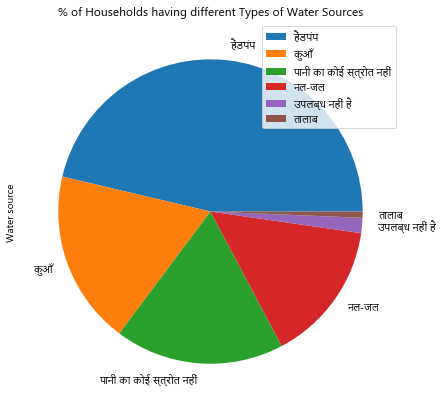

```python
hh_hvng_wtr_src_type_pct.plot.pie(figsize=[10,7],
                          title="% of Households having different Types of Water Sources",
                          legend=True)
```

### Availability of Toilets and Water Source in the Households

```
Has Toilet                   हाँ    नहीं
Water source
हैंडपंप                   275855  183585
कुआँ                      114660   68576
नल-जल                      74443   74157
उपलब्ध नहीं है             11240    4724
पानी का कोई स्त्रोत नहीं   76106  102152
तालाब                       3741    2796
```

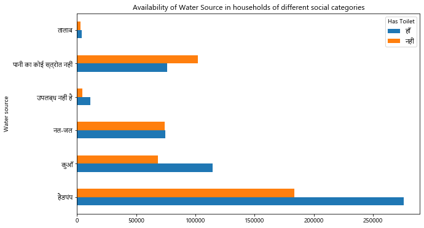

```python
hh_tlt_n_wtr_src_cnt = pd.crosstab(index=raw_data["Water source"], columns=raw_data["Has Toilet"])
print(hh_tlt_n_wtr_src_cnt)
hh_tlt_n_wtr_src_cnt.plot.barh(figsize=[10,6],
                               title="Availability of Water Source in households of different social categories",
                               table=False)
```

#### Observation:

1. Handpump is the major source of water in households (46% of households use handpumps)
2. Water Supply scheme is available in only 15% of the households.
3. 18.5% of the households rely on wells
4. Around 87 Thousand households having toilets has no water source

# Section 3: Status of toilets across State and Districts

```python
raw_data['% Headed by Women'] = raw_data['Sub-category'].apply(lambda x: 100 if (x=="Women Headed HH") else 0)
```

```python
raw_data['% Headed by PH'] = raw_data['Sub-category'].apply(lambda x: 100 if (x=="PH") else 0)
```

```python
raw_data['% Having No Toilet'] = pd.to_numeric(raw_data['Has Toilet'].apply(lambda x: 100 if (x=="नहीं") else 0))
```

```python
raw_data['% Having No Water Source'] = pd.to_numeric(raw_data['Water source'].apply(lambda x: 100 if (x=="उपलब्ध नहीं है") else 0))
```

```python
raw_data['% Households having Toilet but no Water Source'] = np.where((raw_data['Has Toilet']=="हाँ") & (raw_data['Water source']=='उपलब्ध नहीं है'),100,0)
```

```python
raw_data.pivot_table(index=['State','District'],
                     values=['Total Household',
                             '% Headed by Women',
                             '% Headed by PH',
                             '% Having No Toilet',
                             '% Having No Water Source',
                            '% Households having Toilet but no Water Source'],
                     aggfunc={'Total Household':np.sum,
                              '% Headed by Women':np.mean,
                              '% Headed by PH':np.mean,
                              '% Having No Toilet':np.mean,
                              '% Having No Water Source':np.mean,
                             '% Households having Toilet but no Water Source':np.mean},
                    margins=True)
```

| State | District | % Having No Toilet | % Having No Water Source | % Headed by PH | % Headed by Women | % Households having Toilet but no Water Source | Total Household |
| --- | --- | --- | --- | --- | --- | --- | --- |
| Madhya Pradesh | AGAR MALWA | 53.157339 | 16.494192 | 0.105597 | 1.414995 | 7.222809 | 4735 |
|  | ALIRAJPUR | 23.186078 | 1.258367 | 0.294511 | 2.248996 | 0.803213 | 3735 |
|  | ANUPPUR | 16.122392 | 1.868345 | 0.316669 | 4.366069 | 1.789178 | 25263 |
|  | ASHOKNAGAR | 21.968758 | 0.619886 | 0.173568 | 1.810067 | 0.396727 | 4033 |
|  | BALAGHAT | 47.104415 | 0.264159 | 0.130628 | 1.509478 | 0.168365 | 34449 |
|  | BARWANI | 53.505295 | 0.854395 | 0.016243 | 0.545774 | 0.230654 | 30782 |
|  | BETUL | 41.128898 | 0.204952 | 0.227109 | 2.509278 | 0.160638 | 18053 |
|  | BHIND | 73.057818 | 0.119213 | 0.258295 | 3.079674 | 0.119213 | 5033 |
|  | BHOPAL | 51.266500 | 1.355690 | 0.178380 | 1.534071 | 0.856225 | 2803 |
|  | BURHANPUR | 45.781478 | 0.128744 | 0.094412 | 1.819586 | 0.111578 | 11651 |
|  | CHHATARPUR | 44.997635 | 2.840103 | 0.265357 | 2.845358 | 1.999369 | 38062 |
|  | CHHINDWARA | 34.232963 | 0.515243 | 0.404833 | 2.919708 | 0.423235 | 16303 |
|  | DAMOH | 40.276566 | 0.174506 | 0.311996 | 2.530340 | 0.118982 | 37821 |
|  | DATIA | 73.258679 | 6.226204 | 0.268757 | 1.858903 | 3.717805 | 4465 |
|  | DEWAS | 63.751594 | 2.590880 | 0.159439 | 1.793686 | 1.817602 | 12544 |
|  | DHAR | 35.093452 | 0.287544 | 0.169912 | 1.816756 | 0.013070 | 7651 |
|  | DINDORI | 38.060449 | 3.630632 | 0.074170 | 2.154645 | 3.048396 | 26965 |
|  | GUNA | 42.552402 | 0.445186 | 0.217956 | 1.423669 | 0.329252 | 21564 |
|  | GWALIOR | 48.527969 | 14.278705 | 0.147203 | 1.962709 | 9.813543 | 2038 |
|  | HARDA | 33.769370 | 4.930570 | 0.221373 | 0.905615 | 4.185953 | 4969 |
|  | HOSHANGABAD | 38.712057 | 0.305649 | 0.316189 | 1.138280 | 0.252951 | 9488 |
|  | INDORE | 44.748858 | 3.196347 | 0.000000 | 2.648402 | 2.283105 | 1095 |
|  | JABALPUR | 67.084266 | 0.523341 | 0.181962 | 1.442811 | 0.083735 | 62101 |
|  | JHABUA | 21.305585 | 2.073664 | 0.262015 | 1.467286 | 1.280132 | 13358 |
|  | KATNI | 33.884529 | 8.650972 | 0.228886 | 1.901158 | 6.189275 | 21408 |
|  | KHANDWA | 48.582090 | 8.544776 | 0.253731 | 2.417910 | 6.611940 | 13400 |
|  | KHARGONE | 51.152917 | 0.502647 | 0.346485 | 2.608399 | 0.348925 | 40983 |
|  | MANDLA | 33.762246 | 1.870518 | 0.333300 | 3.021917 | 1.395819 | 49505 |
|  | MANDSAUR | 44.483088 | 3.121468 | 0.373881 | 2.904095 | 1.947657 | 11501 |
|  | MORENA | 67.230646 | 1.069433 | 0.351157 | 2.968875 | 0.686353 | 6265 |
|  | NARSINGHPUR | 31.781227 | 2.498152 | 0.251293 | 1.315595 | 1.906874 | 6765 |
|  | NEEMUCH | 24.580080 | 0.745209 | 0.449491 | 2.093683 | 0.437663 | 8454 |
|  | PANNA | 48.104853 | 0.123982 | 0.177117 | 1.499587 | 0.106270 | 16938 |
|  | RAISEN | 45.313640 | 4.613421 | 0.282640 | 2.024070 | 3.482859 | 10968 |
|  | RAJGARH | 47.927098 | 4.898858 | 0.336471 | 2.283196 | 3.769277 | 24965 |
|  | RATLAM | 28.409947 | 1.130369 | 0.195931 | 2.878674 | 0.783723 | 6635 |
|  | REWA | 49.498140 | 0.083517 | 0.211070 | 2.131957 | 0.069850 | 65855 |
|  | SAGAR | 30.954604 | 1.178667 | 0.151710 | 1.668806 | 0.700198 | 17138 |
|  | SATNA | 38.418842 | 0.335148 | 0.161613 | 1.447893 | 0.254342 | 75489 |
|  | SEHORE | 27.703495 | 16.009852 | 0.269763 | 1.254985 | 11.330049 | 8526 |
|  | SEONI | 52.851994 | 1.244190 | 0.599172 | 3.040124 | 0.912195 | 63254 |
|  | SHAHDOL | 22.188053 | 0.223651 | 0.242289 | 2.432206 | 0.223651 | 10731 |
|  | SHAJAPUR | 34.478317 | 9.188493 | 0.042937 | 1.116359 | 6.225848 | 2329 |
|  | SHEOPUR | 45.013477 | 0.539084 | 0.404313 | 2.695418 | 0.134771 | 1484 |
|  | SHIVPURI | 57.960854 | 0.064057 | 0.288256 | 2.686833 | 0.060498 | 28100 |
|  | SIDHI | 32.675070 | 0.140056 | 0.541550 | 2.973856 | 0.084034 | 21420 |
|  | SINGROULI | 23.271695 | 1.008977 | 0.326095 | 2.075501 | 0.947595 | 26066 |
|  | TIKAMGARH | 42.408807 | 0.903713 | 0.410779 | 1.906014 | 0.739402 | 6086 |
|  | UJJAIN | 62.607919 | 0.059542 | 0.312593 | 1.935100 | 0.044656 | 6718 |
|  | UMARIA | 33.374786 | 0.507798 | 0.062179 | 0.880875 | 0.093269 | 19299 |
|  | VIDISHA | 58.415233 | 0.298350 | 0.324675 | 1.978764 | 0.285188 | 22792 |
| All |  | 43.949054 | 1.609217 | 0.263700 | 2.147303 | 1.133025 | 992035 |